# R Programming

## Key Things to Remember

## Not all charts need to be pretty!

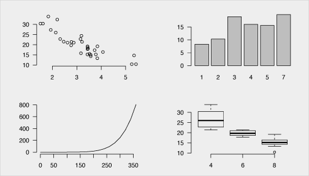

## What to Remember from this Section

> Exploratory data analysis plotting should be quick and simple and base R excels at this

| Visualization Dimension | Visualization | Function |
| --- | --- | --- |
| Univariate | Histogram | `hist()` |
|  | Bar chart | `barplot()` |
|  | Box plot | `boxplot()` |
|  | Stem & leaf | `stem()` |
| Bivariate | Scatter plot | `plot()` |
|  | Line chart | `plot()` |
|  | Box plot | `boxplot()` |

## What to Remember from this Section

In R, graphs are typically created interactively:

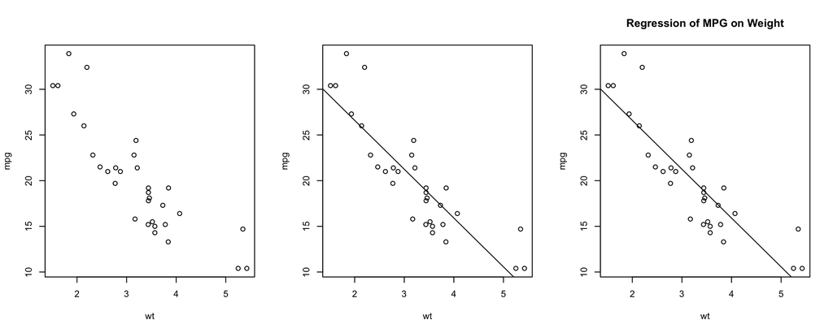

```r
attach(mtcars)
plot(wt, mpg)
abline(lm(mpg~wt))
title("Regression of MPG on Weight")
```

## What to Remember from this Section

> - You can specify fonts, colors, line styles, axes, reference lines, etc. by specifying [graphical parameters](http://www.statmethods.net/advgraphs/parameters.html)
> - This allows a wide degree of customization; however…
> - I have found that ggplot is an easier syntax for customization needs

## Univariate Visualizations

## Histogram

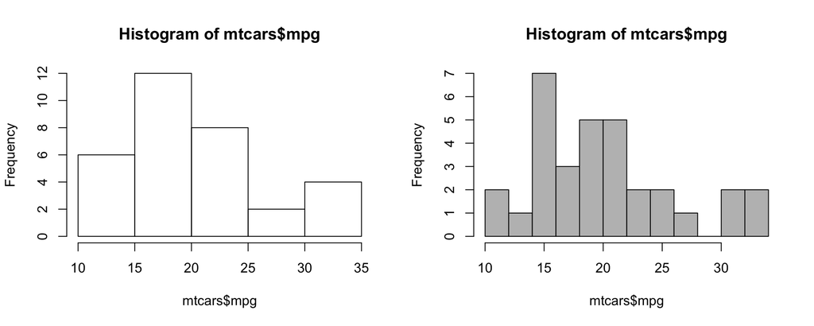

```r
hist(mtcars$mpg)

hist(mtcars$mpg, breaks = 10, col = "grey")
```

## Histogram

A perfect example of why customization with base R is not always enjoyable; in ggplot this is far simpler

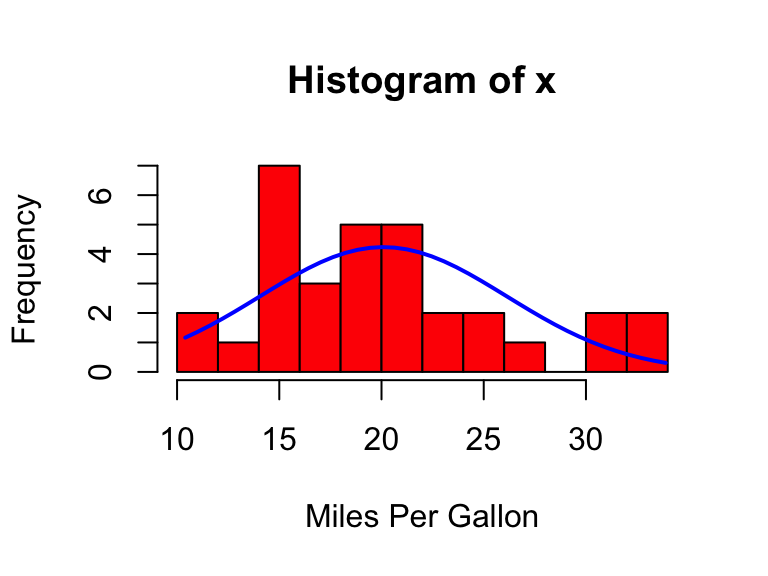

```r
x <- mtcars$mpg

# histogram
h<-hist(x, breaks = 10, col = "red", xlab = "Miles Per Gallon")

# add a normal curve
xfit<-seq(min(x), max(x), length = 40)
yfit<-dnorm(xfit, mean = mean(x), sd = sd(x))
yfit <- yfit * diff(h$mids[1:2]) * length(x)
lines(xfit, yfit, col = "blue", lwd = 2)
```

## Density Plot

Enclose density(x) within plot()

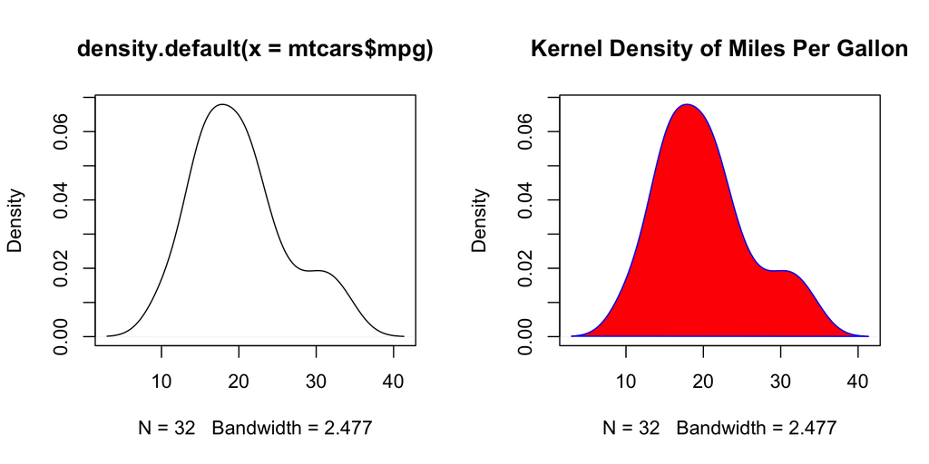

```r
# basic density plot
plot(density(mtcars$mpg))

# fill denisty plot by adding polygon()
polygon(d, col = "red", border = "blue")
```

## Your Turn

Import the `facebook.tsv` file in the data folder

> Assess the distribution of age with a histogram. What does this tell you?

## Bar Chart

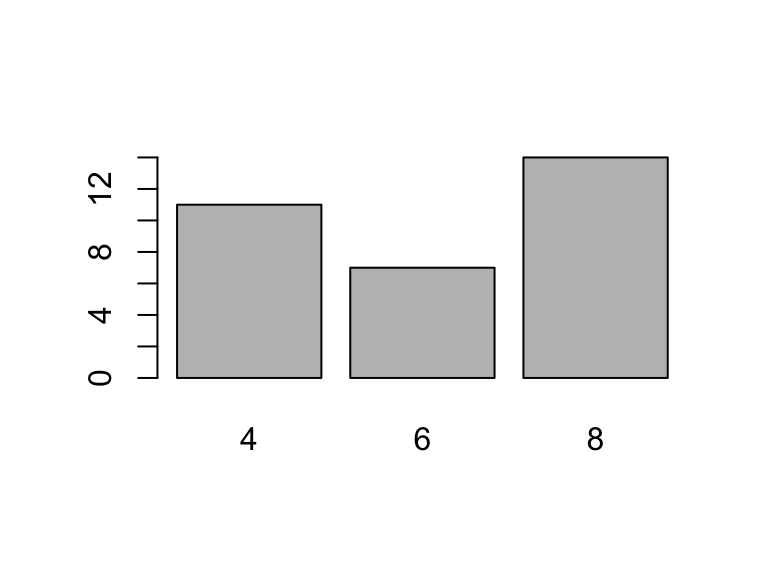

```r
mtcars$cyl
##  [1] 6 6 4 6 8 6 8 4 4 6 6 8 8 8 8 8 8 4 4 4 4 8 8 8 8 4 4 4 8 6 8 4

table(mtcars$cyl)
##
##  4  6  8
## 11  7 14

barplot(table(mtcars$cyl))
```

## Bar Chart

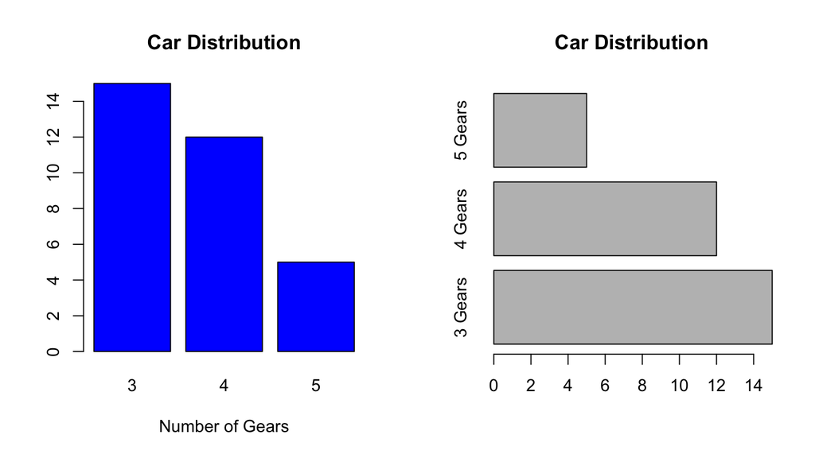

```r
counts <- table(mtcars$gear)

barplot(counts, main = "Car Distribution", xlab = "Number of Gears", col = "blue")

barplot(counts, main = "Car Distribution", horiz = TRUE, names.arg = c("3 Gears", "4 Gears", "5 Gears"))
```

## Dot Plot

Provides less noise than bar charts when plotting many categories

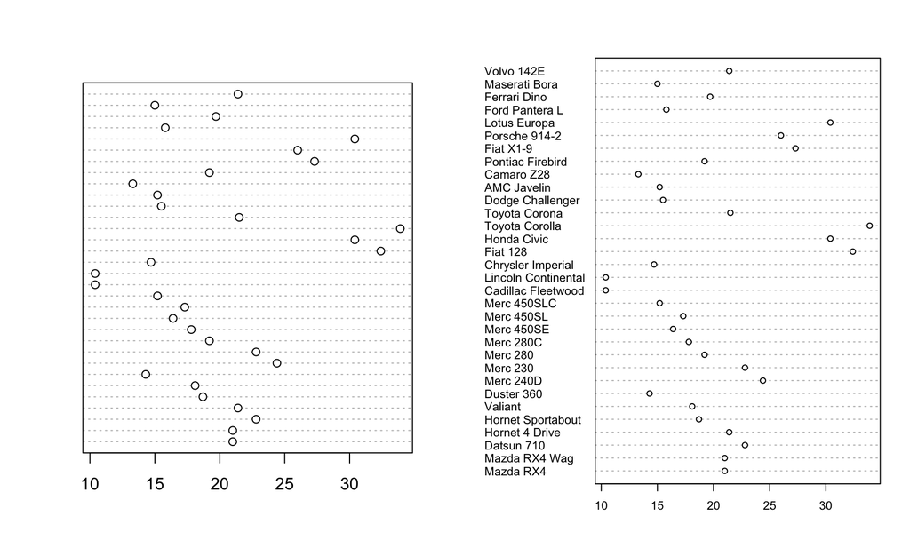

```r
dotchart(mtcars$mpg)

dotchart(mtcars$mpg, labels = row.names(mtcars), cex = .7)
```

## Dot Plot

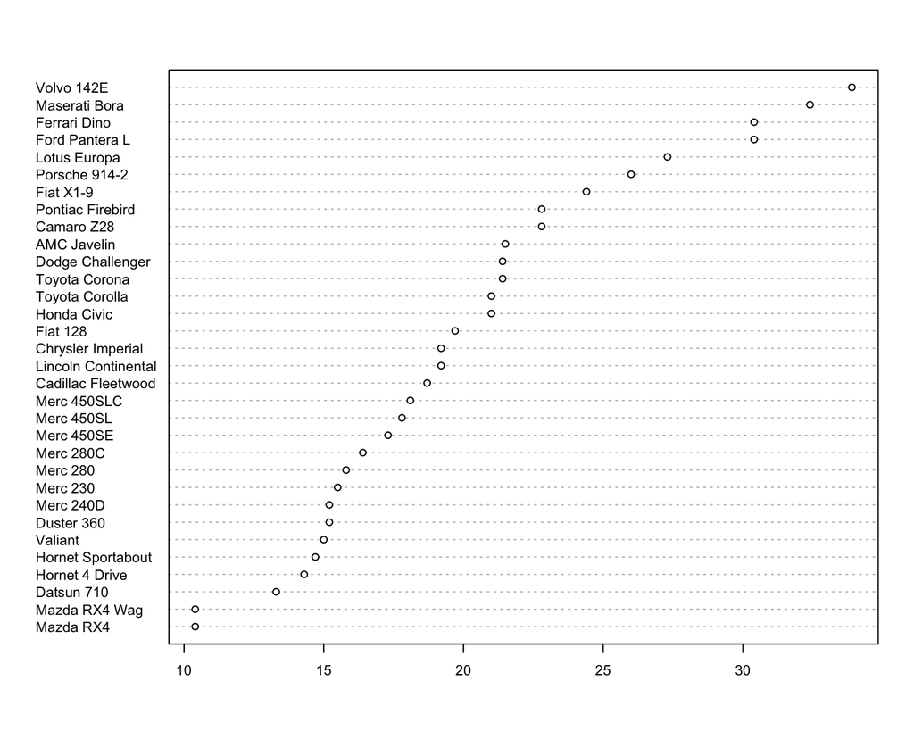

```r
# order the data first to get more understanding
x <- mtcars[order(mtcars$mpg),]
dotchart(x$mpg,labels = row.names(mtcars), cex = .7)
```

## Box Plot

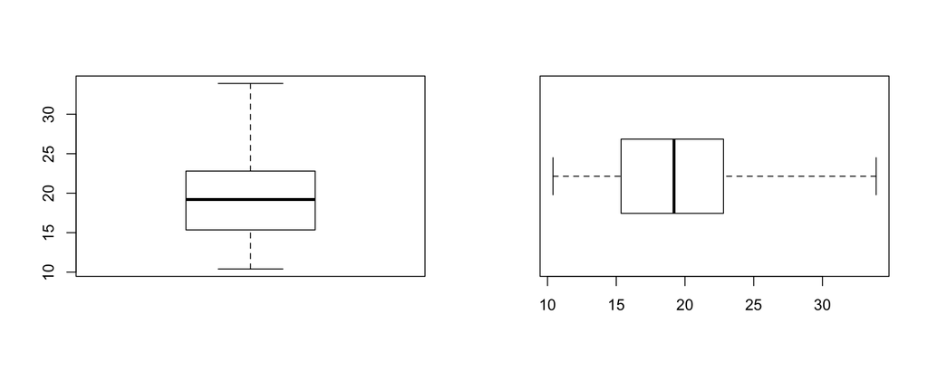

```r
boxplot(mtcars$mpg)
boxplot(mtcars$mpg, horizontal = TRUE)
```

## Your Turn

Import the `reddit.csv` file in the data folder

> 1. Assess the frequency of education levels. What does this tell you?

**Hint:** preceed your plot function with `par(mar = c(5,15,1,1), las = 2)`

> 2. Assess the frequency of states. What does this tell you?

## Stem & Leaf Plot

```r
stem(mtcars$mpg)
```

```
##
##   The decimal point is at the |
##
##   10 | 44
##   12 | 3
##   14 | 3702258
##   16 | 438
##   18 | 17227
##   20 | 00445
##   22 | 88
##   24 | 4
##   26 | 03
##   28 |
##   30 | 44
##   32 | 49
```

## Your Turn

Import the `facebook.tsv` file in the data folder

> 1. Assess the distribution of age with a histogram. What does this tell you?

> 2. Assess the distribution of age with a boxplot. What does this tell you?

> 3. Assess the frequency of each gender. What does this tell you?

## Bivariate Visualizations

## Scatter Plot

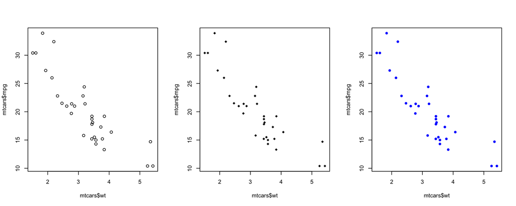

```r
plot(x = mtcars$wt, y = mtcars$mpg)
plot(x = mtcars$wt, y = mtcars$mpg, pch = 18)
plot(x = mtcars$wt, y = mtcars$mpg, pch = 16, col = "blue")
```

## Scatter Plot Matrix

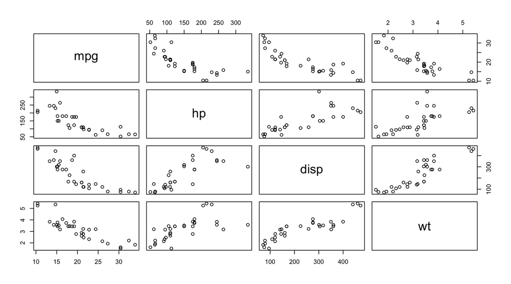

```r
plot(mtcars[, c("mpg", "hp", "disp", "wt")])
```

## Line Chart

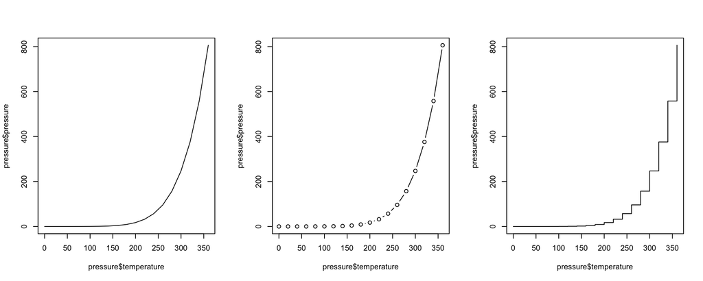

```r
plot(x = pressure$temperature, y = pressure$pressure, type = "l")
plot(x = pressure$temperature, y = pressure$pressure, type = "b")
plot(x = pressure$temperature, y = pressure$pressure, type = "s")
```

## Line Chart

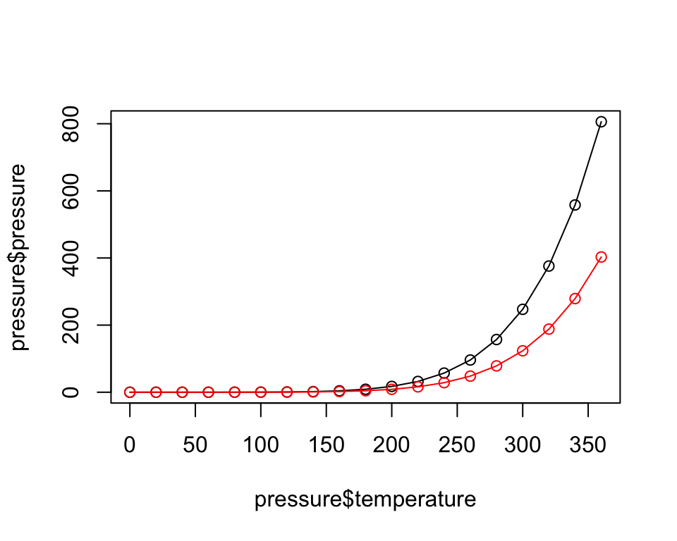

```r
plot(x = pressure$temperature, y = pressure$pressure, type = "l")       # initial plot
points(x = pressure$temperature, y = pressure$pressure)                 # add points
lines(x = pressure$temperature, y = pressure$pressure/2, col = "red")   # add second line
points(x = pressure$temperature, y = pressure$pressure/2, col = "red")  # add points to second line
```

## Box Plot

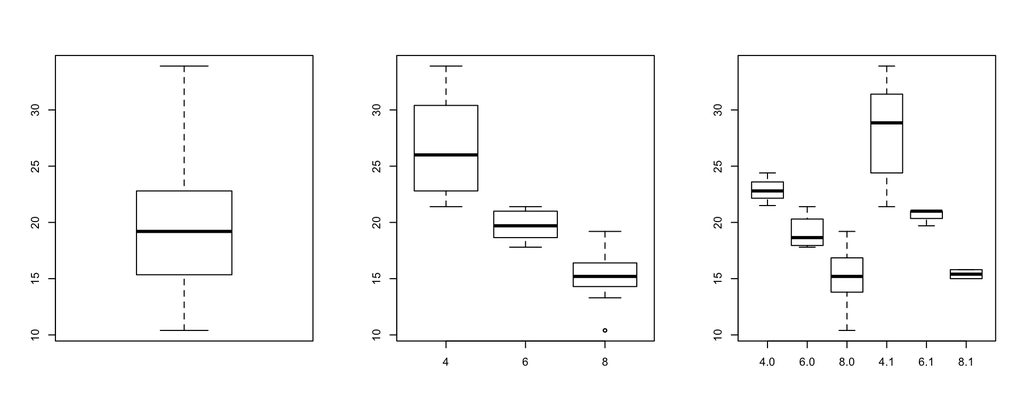

```r
boxplot(mtcars$mpg)
boxplot(mpg ~ cyl, data = mtcars)
boxplot(mpg ~ cyl + am, data = mtcars)
```

## Your Turn

Continuing with the `facebook.tsv` data…

> 1. Plot age and friend count. What does this tell you?

> 2. Assess the distribution of age by gender. What does this tell you?

## Key Things to Remember

## Remember These Functions!

| Visualization | Function |
| --- | --- |
| Histogram | `hist()` |
| Bar chart | `barplot()` |
| Box plot | `boxplot()` |
| Stem & leaf | `stem()` |
| Scatter plot | `plot()` |
| Line chart | `plot()` |
| Box plot | `boxplot()` |

## Break

5 minutes!